# R Notebook

# Introduction

In this blog, I want to give an example of Martingale strategy. For the definition of Martingale strategy, see it on github webpage.[^1] I will use computer simulation to illustrate the operating characteristics of the above strategy.

## Background

Roulette is a game of chance in which a pocket is randomly selected. Gamblers may wager on several aspects of the outcome. For example, one may place a wager that the randomly selected pocket will be red or odd numbered or will be a specific number.

there are 38 pockets of which 2 are green, 18 are red, and 18 are black. The payout for a bet on black (or red) is $1 for each $1 wagered. This means that if a gambler bets $1 on black and the randomly selected pocket is black, then the gambler will get the original $1 wager and an additional $1 as winnings.

# A single play of the Martingale strategy

Takes a state list, spins the roulette wheel, returns the state list with updated values (for example, budget, plays, etc)

state A list with the following entries:  
* **B** number, the budget  
* **W** number, the budget threshold for successfully stoping  
* **L** number, the maximum number of plays  
* **M** number, the casino wager limit  
* **plays** integer, the number of plays executed  
* **previous_wager** number, the wager in the previous play (0 at first play)  
* **previous_win** TRUE/FALSE, indicator if the previous play was a win (TRUE at first play)

```r
library(dplyr)
one_play <- function(state){

    # Wager
    proposed_wager <- ifelse(state$previous_win, 1, 2*state$previous_wager)
    wager <- min(proposed_wager, state$M, state$B)

    # Spin of the wheel
    red <- rbinom(1,1,18/38)

    # Update state
    state$plays <- state$plays + 1
    state$previous_wager <- wager
    if(red){
      # WIN
      state$B <- state$B + wager
      state$previous_win <- TRUE
    }else{
      # LOSE
      state$B <- state$B - wager
      state$previous_win <- FALSE
    }
  state
}
```

In this section, we define a function and use several parameters, such as Wager, Spin of the wheel, Update state. In the upstate state, there are two situations: WIN or LOSE. In the wager part, we use 1 dollar if we win the lastr round, otherwise the wager is twice the money we lost last time. In the spin of the model, we use Binomial Distribution to build a situation in roulette, which there are 38 blocks, we have 18/38 chance to win. The plays count automatically for each spin of the wheel. We define we win when the output is red. For the beginning, the wager we use is 1.

## Stopping rule

Takes the state list and determines if the gambler has to stop

```r
stop_play <- function(state){
  if(state$B <= 0) return(TRUE)
  if(state$plays >= state$L) return(TRUE)
  if(state$B >= state$W) return(TRUE)
  FALSE
}
```

The above mentioned three cases of stopping the game. The first is that the starting budget is 0 or less than 0, we can say we lose what we have. The second situation is that the number of times of play has reached the topline level. In actual situations, the bookmaker may limit the number of bets to avoid risks. The third situation is that we reach the prize what we want. Of cource, in real situation, when a gambler win some money, the gambler would continue to gamble. In this part,we set 3 parameters,B, which stands starting budget, plays, which stands time threshold for stopping and W, which stands winnings threshold for stopping.

## Play roulette to either bankruptcy, success, or play limits

- **B** number, the budget
- **W** number, the budget threshold for successfully stoping
- **L** number, the maximum number of plays
- **M** number, the casino wager limit  
  A vector of budget values calculated after each play.

```r
one_series <- function(
    B = 200
  , W = 300
  , L = 1000
  , M = 100
){

  # initial state
  state <- list(
    B = B
  , W = W
  , L = L
  , M = M
  , plays = 0
  , previous_wager = 0
  , previous_win = TRUE
  )

  # vector to store budget over series of plays
  budget <- rep(NA, L)

  # For loop of plays
  for(i in 1:L){
    new_state <- state %>% one_play
    budget[i] <- new_state$B
    if(new_state %>% stop_play){
      plot(budget-200, xlab = "Time of Play", ylab = "Earnings")
      return(budget[1:i])
    }
    state <- new_state
  }
  budget
}
```

In this section, we create a function called one_series using 4 parameters, which are B, W, L, M. Then we difine the initial state and give numbers to plays, previous_wager and previous_win. In other words the starting wager is 1 because the default is we win from the #0. The second part, we have a vector to store the budgets after each play. As for the loop from the function, the number of loops playing is about when we stop the play, so the max is L and will stop when we stop playing. We define new_state from one_play function using state as a parameter. then we refresh the budget. We stop when our status meets stop_play status, otherwise we continue the loop.

# helper function

```r
get_last <- function(x) x[length(x)]
```

In this section, we define a function called get_last, which get the last number from a vector. For example, a vector has 100 elements with 1, 2 ,……, 100, get_last function use 100 as the output.

# Simulation

```r
walk_out_money <- rep(NA, 1500)
number_of_plays <- rep(NA, 1500)
for(j in seq_along(walk_out_money)){
walk_out_money[j] <- one_series(B = 200, W = 300, L = 1000, M = 100) %>% get_last
number_of_plays[j] <- one_series(B = 200, W = 300, L = 1000, M = 100) %>% length
}
```

In this part, we do a simulation using 1500 times. We count the walk_out_money by using the get_last function onto one_series(B = 200, W = 300, L = 1000, M = 100). It calculate the money we have when we end the play.

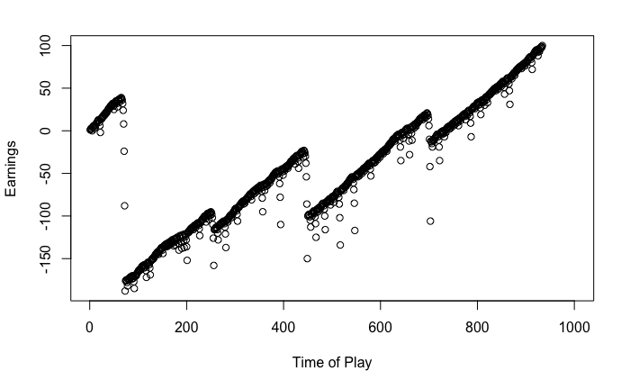

**ADD**The picture above shows the trend of a player winning money. It can be clearly seen that when winning money, the graph tends to a straight line of 45 degrees. But when you lose money, you will lose steeply. The gambler use near 1000 times to win 100 dollars.

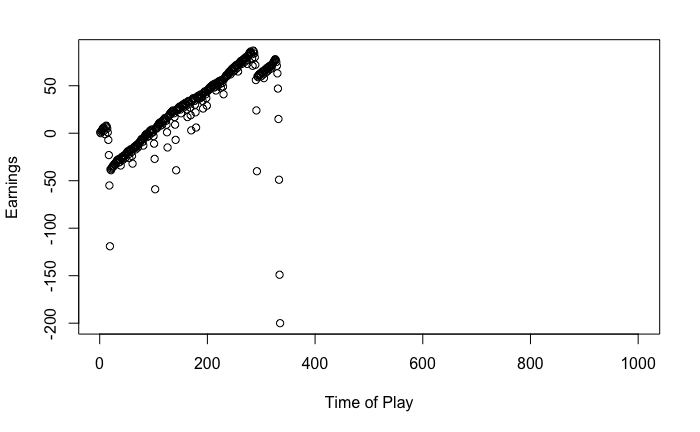

**ADD**The picture above shows the trend of a player losing money. when the gambler lose money, it looks like a straight line. The gambler use just near 350 times to lose 200 dollars. That is because, when we win we can only win 1 dollar each time. But when we lose it in a row, the money lost every time is doubled.

# Walk out money distribution

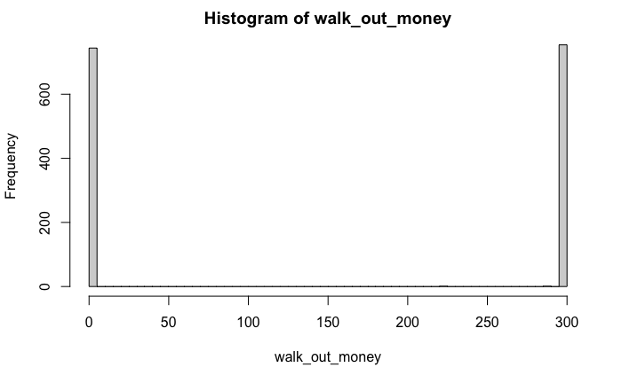

```r
hist(walk_out_money, breaks = 100)
```

In this part, it generate a graph showing the walk-out-money. From the graph, all of the money is 0 or 300, which means, we cannot reach the max number of plays, we will quit the game either lose everything or reach our hoal, and the chance is near half half. the chance we we is littlr higher. In the next part, we calculate the possibilities.

# Estimated probability of walking out with extra cash

```r
mean(walk_out_money > 200)
```

```
[1] 0.504
```

In this part, we calculate the possibilities of we walk-out with money more than 200, which shows 0.504.

# Estimated earnings

```r
mean(walk_out_money - 200)
```

```
[1] -48.86067
```

# Average number of plays

- real mean #

```r
mean(number_of_plays)
```

```
[1] 203.77
```

- original: it calculates one person’s average number of play

```r
length(one_series(B = 200, W = 300, L = 1000, M = 100))
```

[output not shown]

In this part, we calculate the average number of plays. From the chart above, we can obviously conclude we nearly never reach the max number of plays. So what’s the average? it show 203.77 far less than 1000.

Next, we are going to explore more situations by changing patameters.

#Change W to 400 The simulation above use W=300. We know change it into 400 because when we lose, we lose 200, so I want to know what will hapen if we quit by winning 200.

```r
one_series <- function(
    B = 200
  , W = 400
  , L = 1000
  , M = 100
){

  # initial state
  state <- list(
    B = B
  , W = W
  , L = L
  , M = M
  , plays = 0
  , previous_wager = 0
  , previous_win = TRUE
  )

  # vector to store budget over series of plays
  budget <- rep(NA, L)

  # For loop of plays
  for(i in 1:L){
    new_state <- state %>% one_play
    budget[i] <- new_state$B
    if(new_state %>% stop_play){
      return(budget[1:i])
    }
    state <- new_state
  }
  budget
}
```

```r
get_last <- function(x) x[length(x)]
```

```r
walk_out_money <- rep(NA, 1500)
number_of_plays <- rep(NA, 1500)
for(j in seq_along(walk_out_money)){
walk_out_money[j] <- one_series(B = 200, W = 400, L = 1000, M = 100) %>% get_last
number_of_plays[j] <- one_series(B = 200, W = 400, L = 1000, M = 100) %>% length
}
```

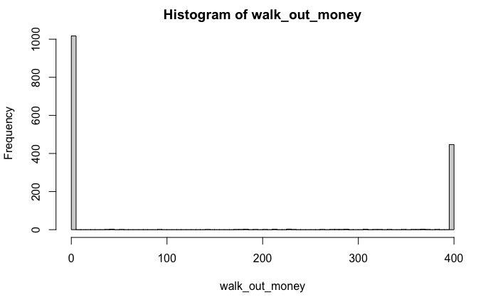

```r
hist(walk_out_money, breaks = 100)
```

**ADD**In this part, it generate a graph showing the walk-out-money. From the graph, all of the money is 0 or 400, which means, we cannot reach the max number of plays, we will quit the game either lose everything or reach our goal, and the chance is about 70%-30%. Comparing the situation before, which is half half, this time we have less chance to quit while we win.

```r
mean(walk_out_money > 200)
```

```
[1] 0.3146667
```

**ADD**The estimated probability of walking out with extra cash for the parameters B = 200, W = 400, L = 1000, M = 100 is 31.47%. This probability is much lower than before which means we are less likely to be profitable in this scenario comparing with W=300.

```r
mean(walk_out_money - 200)
```

```
[1] -75.01067
```

```r
mean(number_of_plays)
```

```
[1] 344.0827
```

**ADD**In this part, we calculate the average number of plays. From the chart above, we can obviously conclude we nearly never reach the max number of plays. So what’s the average? it shows 344.1 far less than 1000. However, still more than W=300. That is caused by we need a longer road to take the money out.

```r
one_series <- function(
    B = 200
  , W = 300
  , L = 200
  , M = 100
){

  # initial state
  state <- list(
    B = B
  , W = W
  , L = L
  , M = M
  , plays = 0
  , previous_wager = 0
  , previous_win = TRUE
  )

  # vector to store budget over series of plays
  budget <- rep(NA, L)

  # For loop of plays
  for(i in 1:L){
    new_state <- state %>% one_play
    budget[i] <- new_state$B
    if(new_state %>% stop_play){
      return(budget[1:i])
    }
    state <- new_state
  }
  budget
}
```

```r
get_last <- function(x) x[length(x)]
```

```r
walk_out_money <- rep(NA, 1500)
number_of_plays <- rep(NA, 1500)
for(j in seq_along(walk_out_money)){
walk_out_money[j] <- one_series(B = 200, W = 300, L = 200, M = 100) %>% get_last
number_of_plays[j] <- one_series(B = 200, W = 300, L = 200, M = 100) %>% length
}
```

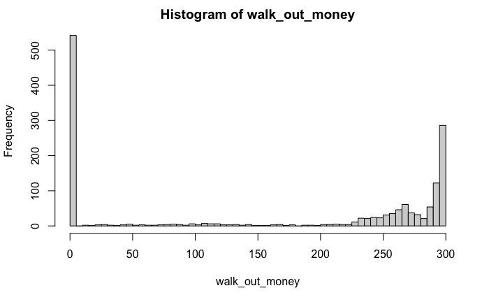

```r
hist(walk_out_money, breaks = 100)
```

```r
mean(walk_out_money > 200)
```

```
[1] 0.5646667
```

**ADD**The estimated probability of walking out with extra cash for the parameters B = 200, W = 300, L = 200, M = 100 is 56.47%. This probability is close as before L = 1000, but a little bit higher, which meand when we limit L,we have more chance to win. And for the expected value, we lose less.

```r
mean(walk_out_money - 200)
```

```
[1] -35.33067
```

**ADD**In this part, we calculate the expected winning and it is -35.33, which larger than L = 1000.Thus, it means when we gamble much, we lose much. No gambling is earning money from expected value!

```r
mean(number_of_plays)
```

```
[1] 156.7193
```

**ADD**When we limit the number of plays to 200, it will drop to 156.7. That is we cut 80% of the upper limit but only reduce 25% average number of plays.

#Change M to 300 The simulation above use M=100, now we put it as 300, which means it does not have the limit on wager.

```r
one_series <- function(
    B = 200
  , W = 300
  , L = 1000
  , M = 300
){

  # initial state
  state <- list(
    B = B
  , W = W
  , L = L
  , M = M
  , plays = 0
  , previous_wager = 0
  , previous_win = TRUE
  )

  # vector to store budget over series of plays
  budget <- rep(NA, L)

  # For loop of plays
  for(i in 1:L){
    new_state <- state %>% one_play
    budget[i] <- new_state$B
    if(new_state %>% stop_play){
      return(budget[1:i])
    }
    state <- new_state
  }
  budget
}
```

```r
get_last <- function(x) x[length(x)]
```

```r
walk_out_money <- rep(NA, 1500)
number_of_plays <- rep(NA, 1500)
for(j in seq_along(walk_out_money)){
walk_out_money[j] <- one_series(B = 200, W = 300, L = 1000, M = 300) %>% get_last
number_of_plays[j] <- one_series(B = 200, W = 300, L = 1000, M = 300) %>% length
}
```

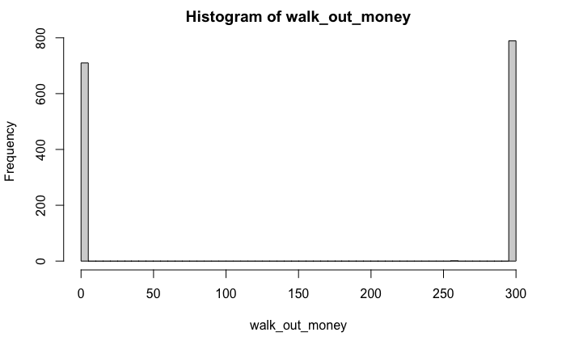

```r
hist(walk_out_money, breaks = 100)
```

**ADD**In this part, it generate a graph showing the walk-out-money. From the graph, all of the money is 0 or 300, all looks similar to M=100. M=100 or M=300 don’t affect too much because it’s very hard to get wager =100 situation or we lose 7 times in a row. Thus, the graph does not change too much.

```r
mean(walk_out_money > 200)
```

```
[1] 0.5266667
```

**ADD**The estimated probability of walking out with extra cash for the parameters B = 200, W = 300, L = 1000, M = 300 is 52.67%. This probability is similar as before M = 100. It shows the Wager does not limit too much. We can speculate that when we reach the wager to 100, it is not a regular event.

```r
mean(walk_out_money - 200)
```

```
[1] -42.02867
```

**ADD**In this part, we calculate the expected winning and it is -42.03. To my surprice, it is a little less than M=100. I think they should look similar, and this time is caused by random error.

```r
mean(number_of_plays)
```

```
[1] 181.1887
```

**ADD**In this part, we calculate the average number of plays, which is 181.2. It is less than we put M = 100. That is because if we lose in a row, we may lose our money quickly because now we can lose 300 dollars for one time, but original version is just 100 dollars.

Now, it shows with the no limit on wager, the expected wining chance and the average earning do not change much, rhe histogram also looks similar as the first situation. Only in the last part, which is the average times of play change much because when we lose in a row, we have more chance to lose everything by putting a bigger wager. However, it does not happen too much because 100 is a huge number, if we reach this level,we need to lose 7 times in a row, which is not a high probability event.

# limitations of the simulation

The limitation of this model is that we generally don’t play games like this. Again, this is just an exhaustive example in one situation. Most people would not use this strategy, but he did analyze its effectiveness. As for simplifications or other sources of uncertainty, it simplified the rules of the casino and turned human emotions into machines. Similarly, people’s expectations will change as gambling changes. Also, there is a default that the casino uses fair props.

# Conclusions

[^1]: https://github.com/thomasgstewart/data-science-5620-Fall-2020/blob/master/deliverables/01-roulette.md